# Lab 1_Data Cleaning

## Lab 1: Data Cleaning

##### Done by: Cherise Malisa

**Part 1: Loading the Data and Initial Assesement**

In the cells that follow the described data set is loaded into a dataframe. The data is then described.

```python
import numpy as np
import pandas as pd
import matplotlib.pyplot as plt
import seaborn as sn

#part a./
data = pd.read_csv("Sacramentorealestatetransactions.csv")
```

```python
#part b.
data.head()
```

|  | street | city | zip | state | beds | baths | sq__ft | type | sale_date | price | latitude | longitude |
| --- | --- | --- | --- | --- | --- | --- | --- | --- | --- | --- | --- | --- |
| 0 | 3526 HIGH ST | SACRAMENTO | 95838 | CA | 2 | 1 | 836 | Residential | Wed May 21 00:00:00 EDT 2008 | 59222 | 38.631913 | -121.434879 |
| 1 | 51 OMAHA CT | SACRAMENTO | 95823 | CA | 3 | 1 | 1167 | Residential | Wed May 21 00:00:00 EDT 2008 | 68212 | 38.478902 | -121.431028 |
| 2 | 2796 BRANCH ST | SACRAMENTO | 95815 | CA | 2 | 1 | 796 | Residential | Wed May 21 00:00:00 EDT 2008 | 68880 | 38.618305 | -121.443839 |
| 3 | 2805 JANETTE WAY | SACRAMENTO | 95815 | CA | 2 | 1 | 852 | Residential | Wed May 21 00:00:00 EDT 2008 | 69307 | 38.616835 | -121.439146 |
| 4 | 6001 MCMAHON DR | SACRAMENTO | 95824 | CA | 2 | 1 | 797 | Residential | Wed May 21 00:00:00 EDT 2008 | 81900 | 38.519470 | -121.435768 |

```python
data.info()
```

```
<class 'pandas.core.frame.DataFrame'>
RangeIndex: 985 entries, 0 to 984
Data columns (total 12 columns):
 #   Column     Non-Null Count  Dtype
---  ------     --------------  -----
 0   street     985 non-null    object
 1   city       985 non-null    object
 2   zip        985 non-null    int64
 3   state      985 non-null    object
 4   beds       985 non-null    int64
 5   baths      985 non-null    int64
 6   sq__ft     985 non-null    int64
 7   type       985 non-null    object
 8   sale_date  985 non-null    object
 9   price      985 non-null    int64
 10  latitude   985 non-null    float64
 11  longitude  985 non-null    float64
dtypes: float64(2), int64(5), object(5)
memory usage: 92.5+ KB
```

**Part 2: Representing Categorical Variables**

The next few cells will contain counts of the unique values of specifed columns containing streets, zipcode and number of bedrooms in the dataset.

```python
unique_street_count = data["street"].value_counts()
print(unique_street_count)
```

```
8306 CURLEW CT         2
4734 14TH AVE          2
1223 LAMBERTON CIR     2
7 CRYSTALWOOD CIR      2
3526 HIGH ST           1
                      ..
2981 WRINGER DR        1
8616 ROCKPORTE CT      1
4128 HILL ST           1
1409 47TH ST           1
3882 YELLOWSTONE LN    1
Name: street, Length: 981, dtype: int64
```

```python
unique_zipcode_count = data["zip"].value_counts()
print(unique_zipcode_count)
```

```
95648    72
95823    61
95828    45
95758    44
95838    37
         ..
95619     1
95614     1
95690     1
95633     1
95722     1
Name: zip, Length: 68, dtype: int64
```

```python
unique_beds_count = data["beds"].value_counts()
print(unique_beds_count)
```

```
3    413
4    258
2    133
0    108
5     59
1     10
6      3
8      1
Name: beds, dtype: int64
```

I think it is better to represent street because many houses can be on the same street.The zip code can also be categorical for the same reason as the street. However for the beds count, integer represents perfectly as it shows the number of bedrooms in the house.

The next cell has these columns which were moslty previously represented as ingeters and objects into categorical data.

```python
convert_colums = {"city": 'category',"state": 'category',"zip": 'category',"beds": 'category',"baths": 'category', "type": 'category'}
data = data.astype(convert_colums)
data.head()
```

|  | street | city | zip | state | beds | baths | sq__ft | type | sale_date | price | latitude | longitude |
| --- | --- | --- | --- | --- | --- | --- | --- | --- | --- | --- | --- | --- |
| 0 | 3526 HIGH ST | SACRAMENTO | 95838 | CA | 2 | 1 | 836 | Residential | Wed May 21 00:00:00 EDT 2008 | 59222 | 38.631913 | -121.434879 |
| 1 | 51 OMAHA CT | SACRAMENTO | 95823 | CA | 3 | 1 | 1167 | Residential | Wed May 21 00:00:00 EDT 2008 | 68212 | 38.478902 | -121.431028 |
| 2 | 2796 BRANCH ST | SACRAMENTO | 95815 | CA | 2 | 1 | 796 | Residential | Wed May 21 00:00:00 EDT 2008 | 68880 | 38.618305 | -121.443839 |
| 3 | 2805 JANETTE WAY | SACRAMENTO | 95815 | CA | 2 | 1 | 852 | Residential | Wed May 21 00:00:00 EDT 2008 | 69307 | 38.616835 | -121.439146 |
| 4 | 6001 MCMAHON DR | SACRAMENTO | 95824 | CA | 2 | 1 | 797 | Residential | Wed May 21 00:00:00 EDT 2008 | 81900 | 38.519470 | -121.435768 |

**Part 3: Exploring continous Variables**

In this part of the lab, histograms are plotted for the last two columns, longitude and latitudes and these variables are continous variables are of continuous value.

# part a.

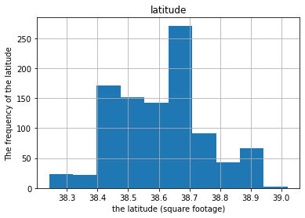

```python
data.hist(column='latitude')
plt.xlabel("the latitude (square footage)")
plt.ylabel("The frequency of the latitude")
plt.show()
```

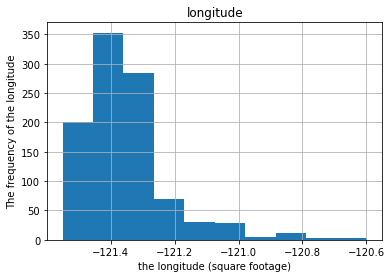

```python
data.hist(column='longitude')
plt.xlabel("the longitude (square footage)")
plt.ylabel("The frequency of the longitude")
plt.show()
```

# part b.

The odd thing is that it seems some of the bars are over lapping which is not expected in a histogram. Also the longitude plot has negatve values which is slightly odd but maybe this has to do with the direction in which the longitude was taken down.

- ask about this one

**Part 4: Exploring Categorical Variables**

In this part the columns that were previously converted into categorical data are plotted below with thier count values.

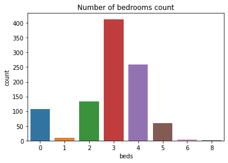

```python
# a.
a = sn.countplot(x=data["beds"])
a.set_title("Number of bedrooms count")
```

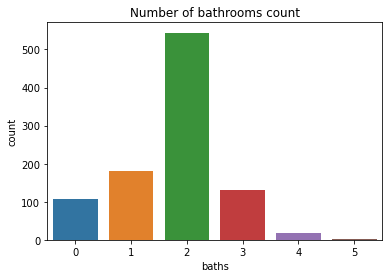

```python
a = sn.countplot(x=data["baths"])
a.set_title("Number of bathrooms count")
```

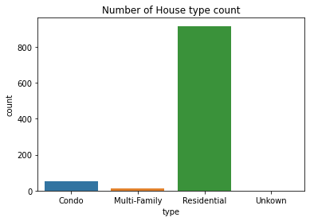

```python
a = sn.countplot(x=data["type"])
a.set_title("Number of House type count")
```

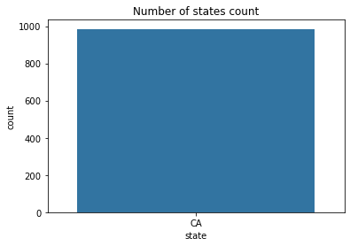

```python
a = sn.countplot(x=data["state"])
a.set_title("Number of states count")
```

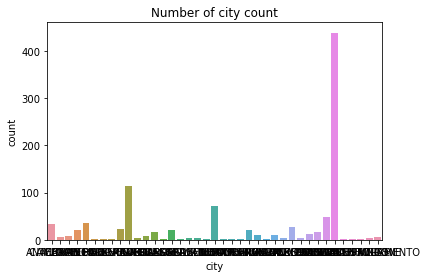

```python
a = sn.countplot(x=data["city"])
a.set_title("Number of city count")
# how to rotate the axis on seaborn.
```

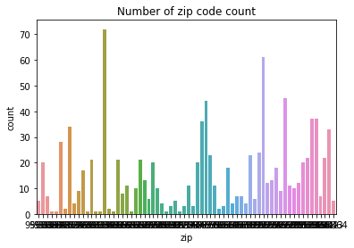

```python
plt.figure()
a = sn.countplot(x=data["zip"])
a.set_title("Number of zip code count")
```

b. Some of the rows have no bedrooms and bathrooms. So those are probably not homes but other types of lots.

**Part 5: Engineering New Varibles**

- Part I

The following cell has a new column added that has boolean values for the square footage home values that are zeros.(Labeles them true of false.

```python
# a
data["empty_lot"] = data["sq__ft"]==0
data.head()
```

|  | street | city | zip | state | beds | baths | sq__ft | type | sale_date | price | latitude | longitude | empty_lot |
| --- | --- | --- | --- | --- | --- | --- | --- | --- | --- | --- | --- | --- | --- |
| 0 | 3526 HIGH ST | SACRAMENTO | 95838 | CA | 2 | 1 | 836 | Residential | Wed May 21 00:00:00 EDT 2008 | 59222 | 38.631913 | -121.434879 | False |
| 1 | 51 OMAHA CT | SACRAMENTO | 95823 | CA | 3 | 1 | 1167 | Residential | Wed May 21 00:00:00 EDT 2008 | 68212 | 38.478902 | -121.431028 | False |
| 2 | 2796 BRANCH ST | SACRAMENTO | 95815 | CA | 2 | 1 | 796 | Residential | Wed May 21 00:00:00 EDT 2008 | 68880 | 38.618305 | -121.443839 | False |
| 3 | 2805 JANETTE WAY | SACRAMENTO | 95815 | CA | 2 | 1 | 852 | Residential | Wed May 21 00:00:00 EDT 2008 | 69307 | 38.616835 | -121.439146 | False |
| 4 | 6001 MCMAHON DR | SACRAMENTO | 95824 | CA | 2 | 1 | 797 | Residential | Wed May 21 00:00:00 EDT 2008 | 81900 | 38.519470 | -121.435768 | False |

The next cell contains a bar plot with the count of how many houses have 0 as the footage and false.

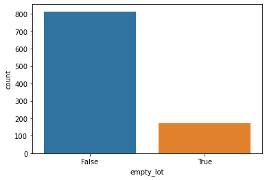

```python
# b
sn.countplot(x=data["empty_lot"])
```

**Part 6: Engineering New Variables**

- Part II

The cell contains, the number of unique home addresses in the dataset (count of address).

```python
# a.
data['street'].value_counts()
```

```
8306 CURLEW CT         2
4734 14TH AVE          2
1223 LAMBERTON CIR     2
7 CRYSTALWOOD CIR      2
3526 HIGH ST           1
                      ..
2981 WRINGER DR        1
8616 ROCKPORTE CT      1
4128 HILL ST           1
1409 47TH ST           1
3882 YELLOWSTONE LN    1
Name: street, Length: 981, dtype: int64
```

I do not think the information is a good feature because there are some adresses with just one home in the dataset.

```python
# b.
data.head(20)
```

|  | street | city | zip | state | beds | baths | sq__ft | type | sale_date | price | latitude | longitude | empty_lot |
| --- | --- | --- | --- | --- | --- | --- | --- | --- | --- | --- | --- | --- | --- |
| 0 | 3526 HIGH ST | SACRAMENTO | 95838 | CA | 2 | 1 | 836 | Residential | Wed May 21 00:00:00 EDT 2008 | 59222 | 38.631913 | -121.434879 | False |
| 1 | 51 OMAHA CT | SACRAMENTO | 95823 | CA | 3 | 1 | 1167 | Residential | Wed May 21 00:00:00 EDT 2008 | 68212 | 38.478902 | -121.431028 | False |
| 2 | 2796 BRANCH ST | SACRAMENTO | 95815 | CA | 2 | 1 | 796 | Residential | Wed May 21 00:00:00 EDT 2008 | 68880 | 38.618305 | -121.443839 | False |
| 3 | 2805 JANETTE WAY | SACRAMENTO | 95815 | CA | 2 | 1 | 852 | Residential | Wed May 21 00:00:00 EDT 2008 | 69307 | 38.616835 | -121.439146 | False |
| 4 | 6001 MCMAHON DR | SACRAMENTO | 95824 | CA | 2 | 1 | 797 | Residential | Wed May 21 00:00:00 EDT 2008 | 81900 | 38.519470 | -121.435768 | False |
| 5 | 5828 PEPPERMILL CT | SACRAMENTO | 95841 | CA | 3 | 1 | 1122 | Condo | Wed May 21 00:00:00 EDT 2008 | 89921 | 38.662595 | -121.327813 | False |
| 6 | 6048 OGDEN NASH WAY | SACRAMENTO | 95842 | CA | 3 | 2 | 1104 | Residential | Wed May 21 00:00:00 EDT 2008 | 90895 | 38.681659 | -121.351705 | False |
| 7 | 2561 19TH AVE | SACRAMENTO | 95820 | CA | 3 | 1 | 1177 | Residential | Wed May 21 00:00:00 EDT 2008 | 91002 | 38.535092 | -121.481367 | False |
| 8 | 11150 TRINITY RIVER DR Unit 114 | RANCHO CORDOVA | 95670 | CA | 2 | 2 | 941 | Condo | Wed May 21 00:00:00 EDT 2008 | 94905 | 38.621188 | -121.270555 | False |
| 9 | 7325 10TH ST | RIO LINDA | 95673 | CA | 3 | 2 | 1146 | Residential | Wed May 21 00:00:00 EDT 2008 | 98937 | 38.700909 | -121.442979 | False |
| 10 | 645 MORRISON AVE | SACRAMENTO | 95838 | CA | 3 | 2 | 909 | Residential | Wed May 21 00:00:00 EDT 2008 | 100309 | 38.637663 | -121.451520 | False |
| 11 | 4085 FAWN CIR | SACRAMENTO | 95823 | CA | 3 | 2 | 1289 | Residential | Wed May 21 00:00:00 EDT 2008 | 106250 | 38.470746 | -121.458918 | False |
| 12 | 2930 LA ROSA RD | SACRAMENTO | 95815 | CA | 1 | 1 | 871 | Residential | Wed May 21 00:00:00 EDT 2008 | 106852 | 38.618698 | -121.435833 | False |
| 13 | 2113 KIRK WAY | SACRAMENTO | 95822 | CA | 3 | 1 | 1020 | Residential | Wed May 21 00:00:00 EDT 2008 | 107502 | 38.482215 | -121.492603 | False |
| 14 | 4533 LOCH HAVEN WAY | SACRAMENTO | 95842 | CA | 2 | 2 | 1022 | Residential | Wed May 21 00:00:00 EDT 2008 | 108750 | 38.672914 | -121.359340 | False |
| 15 | 7340 HAMDEN PL | SACRAMENTO | 95842 | CA | 2 | 2 | 1134 | Condo | Wed May 21 00:00:00 EDT 2008 | 110700 | 38.700051 | -121.351278 | False |
| 16 | 6715 6TH ST | RIO LINDA | 95673 | CA | 2 | 1 | 844 | Residential | Wed May 21 00:00:00 EDT 2008 | 113263 | 38.689591 | -121.452239 | False |
| 17 | 6236 LONGFORD DR Unit 1 | CITRUS HEIGHTS | 95621 | CA | 2 | 1 | 795 | Condo | Wed May 21 00:00:00 EDT 2008 | 116250 | 38.679776 | -121.314089 | False |
| 18 | 250 PERALTA AVE | SACRAMENTO | 95833 | CA | 2 | 1 | 588 | Residential | Wed May 21 00:00:00 EDT 2008 | 120000 | 38.612099 | -121.469095 | False |
| 19 | 113 LEEWILL AVE | RIO LINDA | 95673 | CA | 3 | 2 | 1356 | Residential | Wed May 21 00:00:00 EDT 2008 | 121630 | 38.689999 | -121.463220 | False |

The next cell has a function that extracts the street types from the addresses in the dataset (Ave, Dr,CT).

By splitting the address by a space and returning the last value from the address sting.(seen in part c & d).

```python
# c.
# remove all the numbers from the address as well.
import re
def get_street_type(address):
    pattern = r'[0-9]'
    line = re.sub(pattern, "",address)
    if "Unit" in address:
        i = line.find("Unit")
        before = line[:i]
        street_type = list(filter(None,before.split(" ")))[-1]
    else:
        street_type = list(filter(None,line.split(" ")))[-1]
    return street_type
```

```python
# d.
data["street_type"] = data['street'].apply(get_street_type).astype('category')
data.head(20)
```

|  | street | city | zip | state | beds | baths | sq__ft | type | sale_date | price | latitude | longitude | empty_lot | street_type |
| --- | --- | --- | --- | --- | --- | --- | --- | --- | --- | --- | --- | --- | --- | --- |
| 0 | 3526 HIGH ST | SACRAMENTO | 95838 | CA | 2 | 1 | 836 | Residential | Wed May 21 00:00:00 EDT 2008 | 59222 | 38.631913 | -121.434879 | False | ST |
| 1 | 51 OMAHA CT | SACRAMENTO | 95823 | CA | 3 | 1 | 1167 | Residential | Wed May 21 00:00:00 EDT 2008 | 68212 | 38.478902 | -121.431028 | False | CT |
| 2 | 2796 BRANCH ST | SACRAMENTO | 95815 | CA | 2 | 1 | 796 | Residential | Wed May 21 00:00:00 EDT 2008 | 68880 | 38.618305 | -121.443839 | False | ST |
| 3 | 2805 JANETTE WAY | SACRAMENTO | 95815 | CA | 2 | 1 | 852 | Residential | Wed May 21 00:00:00 EDT 2008 | 69307 | 38.616835 | -121.439146 | False | WAY |
| 4 | 6001 MCMAHON DR | SACRAMENTO | 95824 | CA | 2 | 1 | 797 | Residential | Wed May 21 00:00:00 EDT 2008 | 81900 | 38.519470 | -121.435768 | False | DR |
| 5 | 5828 PEPPERMILL CT | SACRAMENTO | 95841 | CA | 3 | 1 | 1122 | Condo | Wed May 21 00:00:00 EDT 2008 | 89921 | 38.662595 | -121.327813 | False | CT |
| 6 | 6048 OGDEN NASH WAY | SACRAMENTO | 95842 | CA | 3 | 2 | 1104 | Residential | Wed May 21 00:00:00 EDT 2008 | 90895 | 38.681659 | -121.351705 | False | WAY |
| 7 | 2561 19TH AVE | SACRAMENTO | 95820 | CA | 3 | 1 | 1177 | Residential | Wed May 21 00:00:00 EDT 2008 | 91002 | 38.535092 | -121.481367 | False | AVE |
| 8 | 11150 TRINITY RIVER DR Unit 114 | RANCHO CORDOVA | 95670 | CA | 2 | 2 | 941 | Condo | Wed May 21 00:00:00 EDT 2008 | 94905 | 38.621188 | -121.270555 | False | DR |
| 9 | 7325 10TH ST | RIO LINDA | 95673 | CA | 3 | 2 | 1146 | Residential | Wed May 21 00:00:00 EDT 2008 | 98937 | 38.700909 | -121.442979 | False | ST |
| 10 | 645 MORRISON AVE | SACRAMENTO | 95838 | CA | 3 | 2 | 909 | Residential | Wed May 21 00:00:00 EDT 2008 | 100309 | 38.637663 | -121.451520 | False | AVE |
| 11 | 4085 FAWN CIR | SACRAMENTO | 95823 | CA | 3 | 2 | 1289 | Residential | Wed May 21 00:00:00 EDT 2008 | 106250 | 38.470746 | -121.458918 | False | CIR |
| 12 | 2930 LA ROSA RD | SACRAMENTO | 95815 | CA | 1 | 1 | 871 | Residential | Wed May 21 00:00:00 EDT 2008 | 106852 | 38.618698 | -121.435833 | False | RD |
| 13 | 2113 KIRK WAY | SACRAMENTO | 95822 | CA | 3 | 1 | 1020 | Residential | Wed May 21 00:00:00 EDT 2008 | 107502 | 38.482215 | -121.492603 | False | WAY |
| 14 | 4533 LOCH HAVEN WAY | SACRAMENTO | 95842 | CA | 2 | 2 | 1022 | Residential | Wed May 21 00:00:00 EDT 2008 | 108750 | 38.672914 | -121.359340 | False | WAY |
| 15 | 7340 HAMDEN PL | SACRAMENTO | 95842 | CA | 2 | 2 | 1134 | Condo | Wed May 21 00:00:00 EDT 2008 | 110700 | 38.700051 | -121.351278 | False | PL |
| 16 | 6715 6TH ST | RIO LINDA | 95673 | CA | 2 | 1 | 844 | Residential | Wed May 21 00:00:00 EDT 2008 | 113263 | 38.689591 | -121.452239 | False | ST |
| 17 | 6236 LONGFORD DR Unit 1 | CITRUS HEIGHTS | 95621 | CA | 2 | 1 | 795 | Condo | Wed May 21 00:00:00 EDT 2008 | 116250 | 38.679776 | -121.314089 | False | DR |
| 18 | 250 PERALTA AVE | SACRAMENTO | 95833 | CA | 2 | 1 | 588 | Residential | Wed May 21 00:00:00 EDT 2008 | 120000 | 38.612099 | -121.469095 | False | AVE |
| 19 | 113 LEEWILL AVE | RIO LINDA | 95673 | CA | 3 | 2 | 1356 | Residential | Wed May 21 00:00:00 EDT 2008 | 121630 | 38.689999 | -121.463220 | False | AVE |

The next cell has a count of the unique elements of the street type column.

```python
unique_street_type_count = data["street_type"].value_counts()
print(unique_street_type_count)
```

```
WAY         303
DR          171
CT          126
CIR         113
ST           82
AVE          74
LN           47
RD           28
BLVD         13
PL           10
PKWY          7
CONEJO        1
GRANDE        1
HIGHWAY       1
HL            1
MADERA        1
MARTINA       1
BROADWAY      1
TRAK          1
TRL           1
WALK          1
LOOP          1
Name: street_type, dtype: int64
```

Below is a bar plot of the street types and their count values.

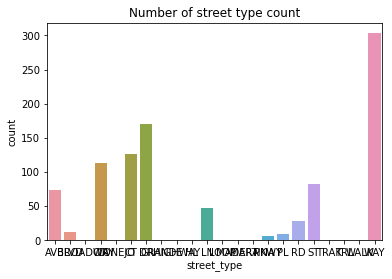

```python
# e
a = sn.countplot(x=data["street_type"])
a.set_title("Number of street type count")
```

**Part 7: Identifying Potential Labels Variables**

part c.

- The price for the real-estate can be used for a regression problem. part d.
- The type of real-eastate can be used for a classification problem.

**Part 8: Identify and remove an outlier record from the dataset**

The rows where a column has been marked as unknown are found and removed from the dataframe in the next cells.

```python
index = data[data.eq("Unkown").any(1)].index
data_index = index

new_data = data.drop(data_index, inplace=True)
# data.head()
```

[output not shown]

```python
data.to_csv(index=False)
```

[output not shown]